# Migration methods

Peter Ralph

2015-12-27

**Note:** if `x` is a raster, `as.matrix(x)` is equal to the *transpose* of `matrix(values(x),nrow=nrow(x))`. We want to access `values` directly, so we’ll stay away from `as.matrix()`.

We’ll start with a very simple example raster:

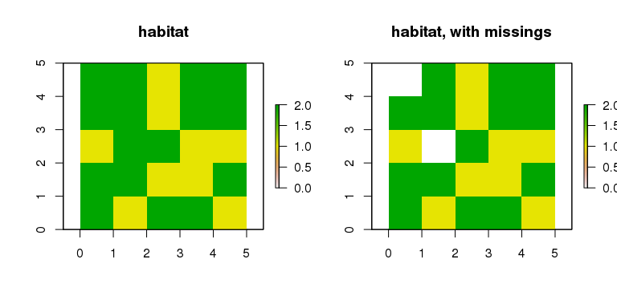

```r
set.seed(42)
habitat <- raster(xmn=0, xmx=5, ymn=0, ymx=5,
      resolution=1,
      crs="+proj=utm +zone=11 +ellps=GRS80 +towgs84=0,0,0,0,0,0,0 +units=m +no_defs")
values(habitat) <- sample( c(1,2), length(habitat), replace=TRUE )
habitat.NA <- habitat
values(habitat.NA)[c(1,12)] <- NA
layout(t(1:2))
plot(habitat,main="habitat",zlim=c(0,2))
plot(habitat.NA,main="habitat, with missings",zlim=c(0,2))
```

And, we’ll need this:

```r
na_to_zero <- function (x) {
    x[is.na(x)] <- 0
    return(x)
}
```

Migration is just smoothing. Let’s make sure we understand what it does with boundaries, and with missing values.

We’ll use a weighting matrix that assigns weight $1/2$ to the center and weight $1/16$ to the surrounding 8 cells.

```r
w <- matrix(1/16,nrow=3,ncol=3)
w[2,2] <- 1/2
w
```

```
##        [,1]   [,2]   [,3]
## [1,] 0.0625 0.0625 0.0625
## [2,] 0.0625 0.5000 0.0625
## [3,] 0.0625 0.0625 0.0625
```

# Types of boundary

We would like to have two types of boundary: **absorbing** boundaries where migrants try to go, but are killed, and **non-boundaries** where migrants just don’t try to go. (The latter is a particular sort of reflecting boundary) We may also want to treat the **internal** boundaries (`NA` cells) and the **external** boundaries (border of the raster) differently.

We will often want to zero out the `NA`s before computation, but need to keep them around in some form to distinguish temporarily empty cells from inhospitable ones.

## Summary and usage

`migration_matrix()`: When precomputing a migration matrix, set absorbing boundary elements to `accessible`, but do not include them in `from` (and `to`). Mark reflecting (non-)boundaries as not `accessible`. External boundaries will be reflecting, so if they should be absorbing, you need to extend the raster and set values appropriately (see examples below).

## **Guts:** Absorbing internal and external boundaries

First, suppose we want migrants to exit at all boundaries. `focal()` allows this by padding the matrix with zeros, and using `na.rm=TRUE`.

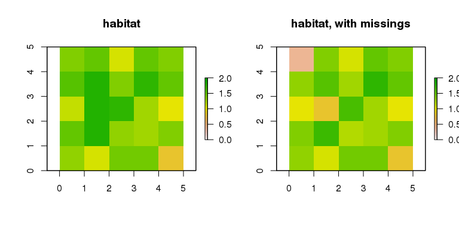

```r
hf1 <- focal( habitat, w=w, pad=TRUE, na.rm=TRUE, padValue=0 )
hf1.NA <- focal( habitat.NA, w=w, pad=TRUE, na.rm=TRUE, padValue=0 )
layout(t(1:2))
plot(hf1,main="habitat",zlim=c(0,2))
plot(hf1.NA,main="habitat, with missings",zlim=c(0,2))
```

Here’s the same computation:

```r
hmat <- matrix(values(habitat),nrow=nrow(habitat),ncol=ncol(habitat))
hmat.NA <- matrix(values(habitat.NA),nrow=nrow(habitat),ncol=ncol(habitat))
expect_equivalent(as.numeric(hmat),values(habitat))
expect_equivalent(as.numeric(hmat.NA),values(habitat.NA))

hmat.pad <- rbind( 0, cbind( 0, hmat, 0 ), 0 )
hmat.NA.pad <- rbind( 0, cbind( 0, hmat.NA, 0 ), 0 )
hmf.NA <- hmf <- 0*hmat
for (dx in c(-1,0,1)) {
    for (dy in c(-1,0,1)) {
        hmf <- hmf + hmat.pad[dx+1+(1:nrow(hmf)),dy+1+(1:ncol(hmf))]*w[2+dx,2+dy]
        add.these <- hmat.NA.pad[dx+1+(1:nrow(hmf)),dy+1+(1:ncol(hmf))]
        hmf.NA <- hmf.NA + ifelse(is.na(add.these),0,add.these)*w[2+dx,2+dy]
    }
}

expect_equivalent(as.numeric(hmf),values(hf1))
expect_equivalent(as.numeric(hmf.NA),values(hf1.NA))
```

Now, let’s do it with `migration_matrix`. So that migrants exit at the boundaries, we need to *not* normalize the matrix (`normalize=NULL`), and compute the matrix for *all* cells, not just the ones that aren’t missing (`from=1:length(habitat)`, or just construct the matrix from the habitat without missing values). Note that if `normalize=NULL` then `migration_matrix` does not normalize the kernel to sum to a constant value, but does multiply the entries by `area/sigma^2`, where area is the area of a cell. In this case, this factor is equal to 1.

```r
M <- migration_matrix( habitat, kern=function(x) { ifelse(x>0,1/16,1/2) }, sigma=1, radius=1, normalize=NULL )
matrix(M[3,],nrow=nrow(habitat))
```

```
##        [,1]   [,2] [,3] [,4] [,5]
## [1,] 0.0000 0.0000    0    0    0
## [2,] 0.0625 0.0625    0    0    0
## [3,] 0.5000 0.0625    0    0    0
## [4,] 0.0625 0.0625    0    0    0
## [5,] 0.0000 0.0000    0    0    0
```

```r
expect_equal( hmf, matrix(M%*%as.numeric(hmat),nrow=nrow(hmf)) )
expect_equal( hmf.NA, matrix(M%*%na_to_zero(as.numeric(hmat.NA)),nrow=nrow(hmf)) )
```

## **Guts:** Absorbing external, not internal, boundaries

Now, suppose we want migrants to exit at the external boundaries, but not internal ones. To make the internal boundaries reflecting, in `focal()` we need to pad the matrix with zeros, and use `fun=weighted.mean` instead of `fun=sum`, with `na.rm=TRUE`. (This will be less efficient than with the default, `fun=sum`.) Note that `focal` returns locally `fun(w*x)`, where `x` is the neighborhood of values, so we need to replace `w` by the matrix of `1`s, and use `weighted.mean` rather than `mean`.

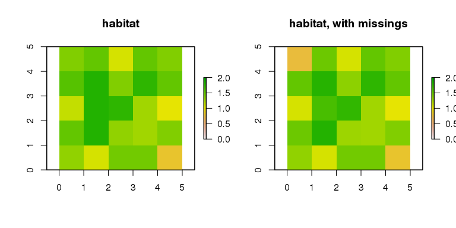

```r
wm.fun <- function (x, na.rm) { weighted.mean(x,w=w,na.rm=na.rm) }
hf2 <- focal( habitat, w=(w>0), pad=TRUE, fun=wm.fun, na.rm=TRUE, padValue=0 )
hf2.NA <- focal( habitat.NA, w=(w>0), pad=TRUE, fun=wm.fun, na.rm=TRUE, padValue=0 )
layout(t(1:2))
plot(hf2,main="habitat",zlim=c(0,2))
plot(hf2.NA,main="habitat, with missings",zlim=c(0,2))
```

Now, let’s do it with `migration_matrix`. So that migrants do not exit at the internal boundaries, we need to normalize the matrix (`normalize=1`). So that they *can* exit at the external boundaries, we need to compute the migration matrix on a padded layer, and then use the function `subset_migration` that restricts the matrix to the part we want.

```r
pad.extent <- extent(habitat)+c(-1,1,-1,1)*res(habitat) # extends by one cell
pad.habitat <- extend(habitat,pad.extent,value=0)
M <- migration_matrix( pad.habitat, kern=function(x) { ifelse(x>0,1/16,1/2) }, sigma=1, radius=1, normalize=1 )
M <- subset_migration( M, old=pad.habitat, new=habitat )
matrix(M[3,],nrow=nrow(habitat))
```

```
##        [,1]   [,2] [,3] [,4] [,5]
## [1,] 0.0000 0.0000    0    0    0
## [2,] 0.0625 0.0625    0    0    0
## [3,] 0.5000 0.0625    0    0    0
## [4,] 0.0625 0.0625    0    0    0
## [5,] 0.0000 0.0000    0    0    0
```

```r
expect_equal( values(hf2), as.numeric(M%*%values(habitat)) )

pad.habitat.NA <- extend(habitat.NA,pad.extent,value=0)
M.NA <- migration_matrix( pad.habitat.NA, kern=function(x) { ifelse(x>0,1/16,1/2) }, sigma=1, radius=1, normalize=1 )
M.NA <- subset_migration( M.NA, old=pad.habitat.NA, new=habitat.NA  )

expect_equal( values(hf2.NA)[!is.na(values(habitat.NA))], as.numeric(M.NA%*%(values(habitat.NA)[!is.na(values(habitat.NA))])) )
```

## **Guts:** Reflecting internal and external boundaries (non-boundaries)

Now, suppose we want migration to be conservative everywhere. Now, in `focal()` we need to pad the matrix with `NA`s, and use `fun=weighted.mean` instead of `fun=sum`, with `na.rm=TRUE`.

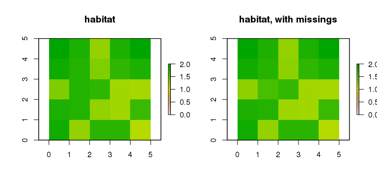

```r
wm.fun <- function (x, na.rm) { weighted.mean(x,w=w,na.rm=na.rm) }
hf3 <- focal( habitat, w=(w>0), pad=TRUE, fun=wm.fun, na.rm=TRUE, padValue=NA )
hf3.NA <- focal( habitat.NA, w=(w>0), pad=TRUE, fun=wm.fun, na.rm=TRUE, padValue=NA )
layout(t(1:2))
plot(hf3,main="habitat",zlim=c(0,2))
plot(hf3.NA,main="habitat, with missings",zlim=c(0,2))
```

Doing this with `migration_matrix` is as easy as setting `normalize=1`.

```r
M <- migration_matrix( habitat, kern=function(x) { ifelse(x>0,1/16,1/2) }, sigma=1, radius=1, normalize=1 )
matrix(M[3,],nrow=nrow(habitat))
```

```
##            [,1]       [,2] [,3] [,4] [,5]
## [1,] 0.00000000 0.00000000    0    0    0
## [2,] 0.07692308 0.07692308    0    0    0
## [3,] 0.61538462 0.07692308    0    0    0
## [4,] 0.07692308 0.07692308    0    0    0
## [5,] 0.00000000 0.00000000    0    0    0
```

```r
expect_equal( values(hf3), as.numeric(M%*%values(habitat)) )

M.NA <- migration_matrix( habitat.NA, kern=function(x) { ifelse(x>0,1/16,1/2) }, sigma=1, radius=1, normalize=1 )
expect_equal( values(hf3.NA)[!is.na(values(habitat.NA))], as.numeric(M.NA%*%(values(habitat.NA)[!is.na(values(habitat.NA))])) )
```

# Less simple example

Here’s a simple habitat we’ll work with. Note that spatial units are in meters; the values are carrying capacities.

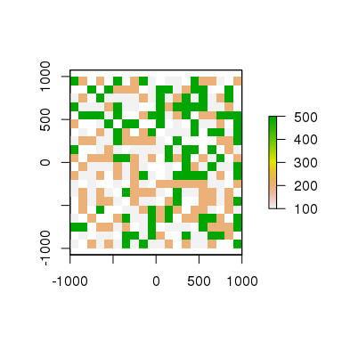

```r
big.habitat <- raster(xmn=-1000, xmx=1000, ymn=-1000, ymx=1000,
      resolution=100,
      crs="+proj=utm +zone=11 +ellps=GRS80 +towgs84=0,0,0,0,0,0,0 +units=m +no_defs")
values(big.habitat) <- sample( 100*c(1,2,5,NA), length(big.habitat), replace=TRUE )
plot(big.habitat)
```

# Migration operations

We can do migration in two ways: either by matrix multiplication, or by doing smoothing operations directly on the layers.

## Matrices

The easiest migration matrix to create is a nearest-neighbor migration:

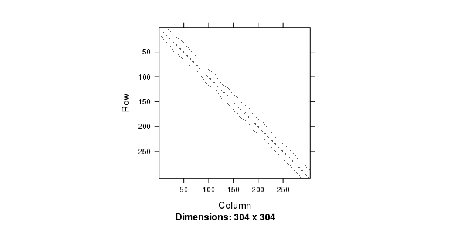

```r
nn.mig <- layer_adjacency(big.habitat)
image(nn.mig)
```

Alternatively, consider a Gaussian kernel:

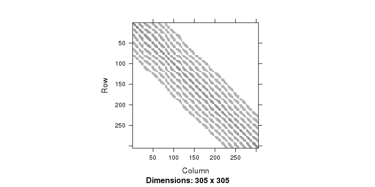

```r
gauss.mig <- migration_matrix(big.habitat,sigma=100,radius=500,kern="gaussian")
image(gauss.mig)
```

Or, a two-dimensional, symmetric Cauchy kernel:

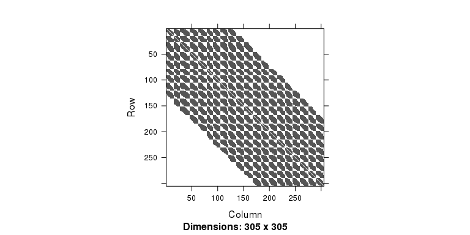

```r
cauchy.mig <- migration_matrix(big.habitat,sigma=100,radius=800,kern="cauchy")
image(cauchy.mig)
```

## Smoothing operations

The `raster` package does smoothing operations directly, with `raster::focal`. For instance, we can assign random values to the non-NA values in the layer and then smooth them with a Gaussian kernel:

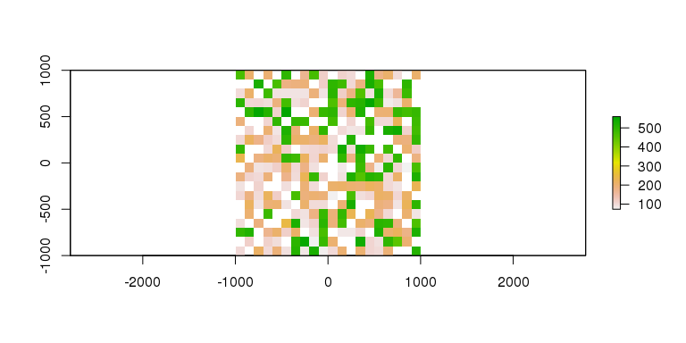

```r
N <- big.habitat
values(N)[!is.na(values(N))] <- rpois(sum(!is.na(values(N))),values(big.habitat)[!is.na(values(N))])
plot(N)
```

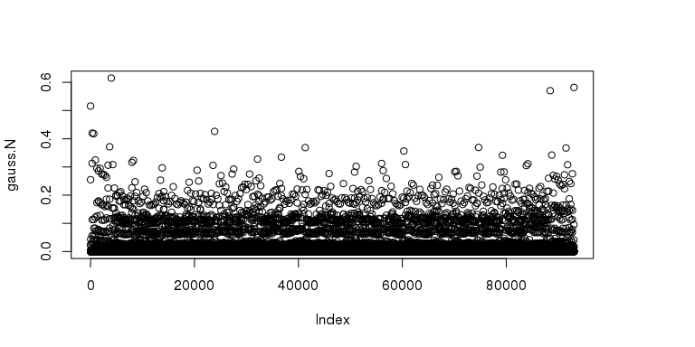

```r
gauss.N <- migration_matrix(N,radius=500,sigma=100,kern="gaussian")
plot(gauss.N)
```